# Data Science 101 in Python: A Crash Course for the Impatient

2019-01-30

So, you want to get into data science but don’t want a 10-hour bootcamp or a textbook thicker than the Yellow Pages phone book? (Yes, I’ve dated myself. I’m Gen X.) Let’s go from zero to data-savvy with just 4 essential skills, like building your first IKEA table but with Python.

We’ll cover:

1. Importing packages
2. Loading data
3. Summarizing data
4. Visualizing data

Let’s get into it. No fluff. Just code + vibes.

## Importing Packages (Like Adding Apps to Your Phone)

Think of Python packages as apps. You don’t build everything from scratch; you install Instagram to scroll, right? Same thing here. These are your must-haves:

Python

```python
import pandas  # For data handling
import numpy  # For math stuff
import matplotlib  # For plotting
import seaborn  # For prettier plots
```

In practice, shortcuts are your friends. Use aliases to keep things tidy:

Python

```python
import pandas as pd  # For data handling
import numpy as np  # For math stuff
import matplotlib.pyplot as plt  # For plotting
import seaborn as sns  # For prettier plots
```

We’ll continue without these shortcuts for clarity, but feel free to use aliases in your own code.

## Loading Data (Like Opening a File in Google Docs)

You need data. You can use a CSV file, which is like a spreadsheet saved in text form. Let’s load a sample dataset from [Seaborn](https://seaborn.pydata.org/) (so you don’t have to download anything).

Python

```python
# Load sample dataset
df = seaborn.load_dataset('titanic')  # Info about Titanic passengers
```

**Pro Tip:** `df` is short for DataFrame. Think of it like a smart table (Excel on steroids).

## Summarizing Data (Like Skimming a Wikipedia Page)

You don’t read every tweet in a thread — you skim the highlights. Let’s do that for our dataset:

Python

```python
df.head()  # First 5 rows
```

```
   survived  pclass     sex   age  sibsp  parch     fare embarked  class    who  adult_male deck  embark_town alive  alone
0         0       3    male  22.0      1      0   7.2500        S  Third    man        True  NaN  Southampton    no  False
1         1       1  female  38.0      1      0  71.2833        C  First  woman       False    C    Cherbourg   yes  False
2         1       3  female  26.0      0      0   7.9250        S  Third  woman       False  NaN  Southampton   yes   True
3         1       1  female  35.0      1      0  53.1000        S  First  woman       False    C  Southampton   yes  False
4         0       3    male  35.0      0      0   8.0500        S  Third    man        True  NaN  Southampton    no   True
```

```python
df.shape  # Rows and columns (like saying "this table has 891 rows")
```

```
(891, 15)
```

```python
df.columns  # List of column names
```

```
Index(['survived', 'pclass', 'sex', 'age', 'sibsp', 'parch', 'fare', 'embarked', 'class', 'who', 'adult_male', 'deck', 'embark_town', 'alive', 'alone'], dtype='object')
```

```python
df.info()  # Data types + missing values
```

```
<class 'pandas.core.frame.DataFrame'>
RangeIndex: 891 entries, 0 to 890
Data columns (total 15 columns):
 #   Column       Non-Null Count  Dtype
---  ------       --------------  -----
 0   survived     891 non-null    int64
 1   pclass       891 non-null    int64
 2   sex          891 non-null    object
 3   age          714 non-null    float64
 4   sibsp        891 non-null    int64
 5   parch        891 non-null    int64
 6   fare         891 non-null    float64
 7   embarked     889 non-null    object
 8   class        891 non-null    category
 9   who          891 non-null    object
 10  adult_male   891 non-null    bool
 11  deck         203 non-null    category
 12  embark_town  889 non-null    object
 13  alive        891 non-null    object
 14  alone        891 non-null    bool
dtypes: bool(2), category(2), float64(2), int64(4), object(5)
memory usage: 80.7+ KB
```

```python
df.describe()  # Quick stats (mean, std, etc.)
```

```
         survived      pclass         age       sibsp       parch        fare
count  891.000000  891.000000  714.000000  891.000000  891.000000  891.000000
mean     0.383838    2.308642   29.699118    0.523008    0.381594   32.204208
std      0.486592    0.836071   14.526497    1.102743    0.806057   49.693429
min      0.000000    1.000000    0.420000    0.000000    0.000000    0.000000
25%      0.000000    2.000000   20.125000    0.000000    0.000000    7.910400
50%      0.000000    3.000000   28.000000    0.000000    0.000000   14.454200
75%      1.000000    3.000000   38.000000    1.000000    0.000000   31.000000
max      1.000000    3.000000   80.000000    8.000000    6.000000  512.329200
```

Wanna see how many survived vs. didn’t?

Python

```python
df['survived'].value_counts()
```

```
survived
0    549
1    342
Name: count, dtype: int64
```

Or maybe: How many people per class?

Python

```python
df['pclass'].value_counts()
```

```
pclass
3    491
1    216
2    184
Name: count, dtype: int64
```

## Visualizing Data (Like Making Your Spotify Wrapped)

Graphs hit different. Let’s plot like pros:

### Bar chart: Who survived?

Python

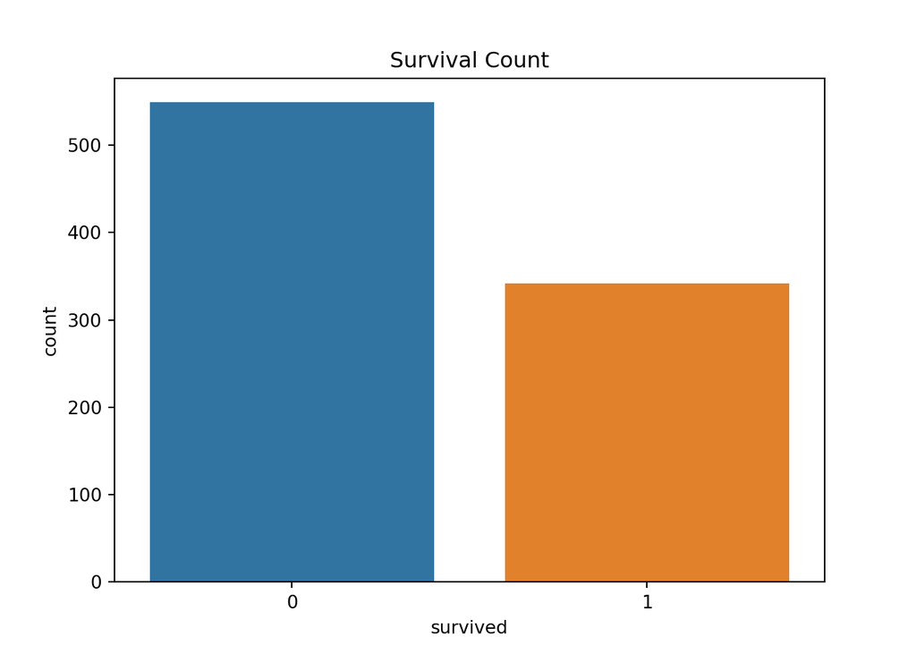

```python
seaborn.countplot(x='survived', data=df)
matplotlib.pyplot.title('Survival Count')
matplotlib.pyplot.show()
```

### Histogram: Age distribution

Python

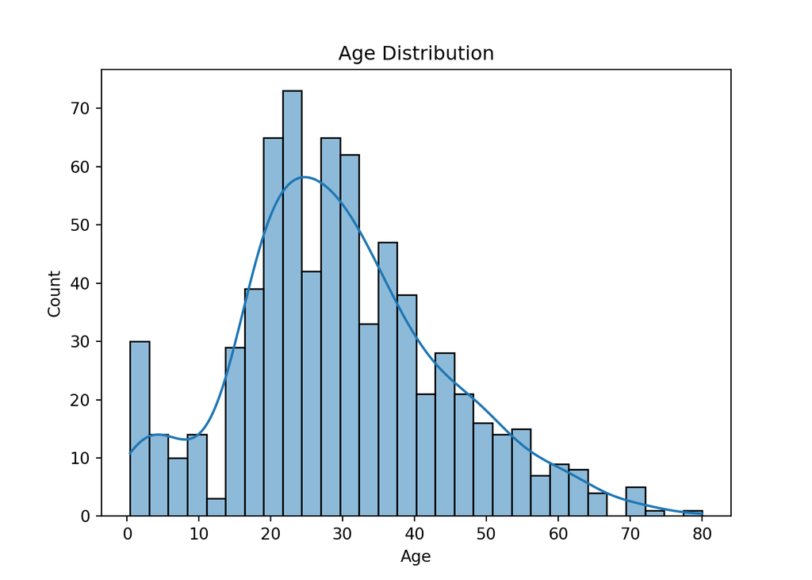

```python
seaborn.histplot(df['age'].dropna(), bins=30, kde=True)
matplotlib.pyplot.title('Age Distribution')
matplotlib.pyplot.xlabel('Age')
matplotlib.pyplot.show()
```